# Predicting Sumo Ranks

Sergei Dakov

2024-11-19

# Porfessional Sumo

### About Sumo

Sumo Wrestling is the national sport of japan. In it two wrestlers push, pull, and jostle to try force their opponent out of the ring, or to make them touch the surface of the ring with any body part except the soles of their feet.

One of the main allures of Sumo is that it is steeped in tradition, featuring rituals that hearken back to ancient japan. While Sumo has been gaining popularity worldwide, with multiple clubs and competitions around the world, Professional Sumo only exists in Japan and is governed by the JSA (Japanese Sumo Association).

In professional Sumo, wrestlers are split into six divisions based on their skill. And as there are no weight classes in sumo, all wrestlers compete in the same competitions against the same opponents.

### The Banzuke

Professional Sumo wrestlers compete in six tournaments per year (one taking place every other month, starting with January). For each tournament a ranking sheet called the Banzuke is published, detailing for each wrestler which division and what place in that division they are in. This Banzuke is re assessed after every tournament and is officially revealed about a month before the following tournament.

Unlike in many other one-on-one sports, there is no ELO or point ranking system for the competitors, instead, the rankings are decided by a council of members of the JSA. This human element makes the unveiling of the Banzuke and eagerly expected event all in itself. Of course, being a prestigious sport the ratings still have to reflect reality to maintain the integrity of competition; thus, despite the secrecy around the way the rankings are decided, certain patterns and apparent guidelines seem to appear.

Fans of the sport enjoy speculating on upcoming Banzuke changes, as well as compete amongst themselves in predicting the way the council would rank the wrestlers. This begs the question: if there are indeed rules and guidelines for how the rankings are decided, could a statistical tool uncover them; and if so, could a statistical or machine learning tool be used to predict wrestler rankings?

# The Data

To test this theory, I have collected the rankings and changes in them since 1995, since this was the year where the last major structural change took place. I limited the data collection to only the top two divisions of professional sumo, as those are the most prestigious divisions that attract the most attention, as well as the fact there is a structural difference between these two divisions and the lower four. The prediction of interest is further limited to only the top division to match most community prediction challenges. In this case, division 2 serves mostly as a buffer, as well as to contain the wrestlers who might be promoted or demoted to and from the top division so they don’t just vanish or appear out of nowhere.

### Processing the data

In each tournament the wrestlers were ranked in order of their placement in the division form 1 to 66, with position 1 being the top position in the Banzuke, this is a little different but consistent with the way wrestlers are ranked in reality. Additionaly, wrestlers who retire from competition are removed from the dataset for the tournament at which they have retired

# Linear Regression

### About Linear Regression

Given a dataset of independent variables X, and a vector of dependent variables Y, Linear regression finds a linear relation that best describes the data; that is, a matrix A so that the result of the multiplication AX minimizes the error (root mean square error in the case of linear regression) from the observed values Y.

### Applying Linear Regression

Since Linear Regression finds a linear relation, it is clear that it works best if there indeed IS a linear relationship. The simplest pattern we can deduce from the Banzuke changes is that there is a very strong correlation between number of positions gained/lost and the win/loss record of the wrestlers, so by defining Y to be the wrestlers change in ranking and X to be the number of wins we can make a simple linear model to help us assess rank change. Of course, as anybody who attempted to predict a Banzuke would tell you, looking only at the win/loss record is extremely reductive, so we can build a more complex model that would account for the other information we gathered such as their previous rank, and whether they are eligible to lose places (some ranks on the Banzuke are afforded more stability than others).

```
##
## Call:
## lm(formula = change ~ ., data = trainset)
##
## Residuals:
##      Min       1Q   Median       3Q      Max
## -22.4600  -2.4016   0.5012   3.1781  14.8875
##
## Coefficients:
##              Estimate Std. Error  t value Pr(>|t|)
## (Intercept) 27.535672   0.611804   45.007  < 2e-16 ***
## rankK       -3.704789   0.380746   -9.730  < 2e-16 ***
## rankM       -3.485157   0.197980  -17.604  < 2e-16 ***
## rankO       -5.938087   0.545074  -10.894  < 2e-16 ***
## rankS       -2.181985   0.389196   -5.606 2.11e-08 ***
## rankY       -6.605532   0.652717  -10.120  < 2e-16 ***
## placement   -0.156712   0.005978  -26.217  < 2e-16 ***
## demotionYES -2.411863   0.503227   -4.793 1.67e-06 ***
## wins        -2.475780   0.019051 -129.955  < 2e-16 ***
## yushoTRUE    4.584268   0.303991   15.080  < 2e-16 ***
## ---
## Signif. codes:  0 '***' 0.001 '**' 0.01 '*' 0.05 '.' 0.1 ' ' 1
##
## Residual standard error: 4.976 on 11258 degrees of freedom
## Multiple R-squared:  0.6471, Adjusted R-squared:  0.6468
## F-statistic:  2293 on 9 and 11258 DF,  p-value: < 2.2e-16
```

Another consideration, is that some ranks are more static compared to the others (specifically, the Ozeki and Yokozuna ranks, which require special conditions for promotion and demotion; as they represent the top of the ratings). Due to that, we can assume that the patterns that hold for the rest of the Banzuke do not apply to those ranks. Additionally, promotion and demotion from those ranks are decided and announced ahead of the rest of the rankings being finalized, thus we can make a prediction without accounting for those ranks as well.

[output not shown]

For Comparison we can perform the same models, and predict the future rank directly, rather than rank change

[output not shown]

```
##
## Call:
## lm(formula = next_rank ~ ., data = train_no_yo)
##
## Residuals:
##      Min       1Q   Median       3Q      Max
## -25.5978  -1.8125   0.4211   2.4180  16.0985
##
## Coefficients:
##              Estimate Std. Error  t value Pr(>|t|)
## (Intercept) 28.603845   0.285925  100.040  < 2e-16 ***
## rankK       -3.334705   0.308603  -10.806  < 2e-16 ***
## rankM       -3.509955   0.160612  -21.854  < 2e-16 ***
## rankS       -0.930697   0.315745   -2.948  0.00321 **
## placement    0.865587   0.004853  178.356  < 2e-16 ***
## wins        -3.068940   0.017176 -178.671  < 2e-16 ***
## yushoTRUE    1.477363   0.301509    4.900 9.73e-07 ***
## ---
## Signif. codes:  0 '***' 0.001 '**' 0.01 '*' 0.05 '.' 0.1 ' ' 1
##
## Residual standard error: 4.03 on 10317 degrees of freedom
## Multiple R-squared:  0.9467, Adjusted R-squared:  0.9466
## F-statistic: 3.052e+04 on 6 and 10317 DF,  p-value: < 2.2e-16
```

## Analysis

### Understanding the Key Parametes

Since we have fit multiple models, we would like to be able to compare them, the main metric of comparison is the R^2 value. This value represents how well the proposed fitted line describes the data, by showing the percentage of variance in the data that is explained by the model. (the exact math is explained in appendix 1, below).

While this is a good metric for how well the model describes the data, it does not tell us much about the models predictive power. Since our main goal is predicting a future Banzuke, this is the metric of higher importance, for this we will use two metrics:

- Accuracy: this metric indicates which percent of guesses were exactly correct, that is the percent of guesses where the predicted rank exactly matches the factual future rank.

Due to the fact that predicting the banzuke is considered a difficult task, many prediction games allow for small leeway in predictions for a reduced score. Following that principle as an auxiliary metric, we will use off-by-one accuracy (meaning: which percent of predictions were within +/- 1 rank from the actual future rank).

- Root mean Square Error (RMSE): Many times, it is useful to know not only whether a model was wrong, but also by how much it was wrong (a model that misses by a small margin is generally better than a model that misses by a lot). For this purpose we use RMSE, this metric allows us to find the mean margin of error in our model.

### Comparing the Models

First, we look at the R squared:

```
## # A tibble: 4 × 2
##   model               value
##   <chr>               <dbl>
## 1 next rank no static 0.947
## 2 next rank full      0.931
## 3 change no static    0.788
## 4 change full         0.647
```

What we can see immediately is that models using the next rank get a better fit than models fitted on rank change, as well as the fact that excluding the elite ranks makes for a better fit as well (reinforcing the suggestion that those ranks operate on a different logic).

It would initially appear that predicting the next rank while omitting the static ranks produces a strong model, with an R squared value of nearly 0.95. Such a value indicates a strong relation and would be a great result for any regression model. Unfortunately we are looking for a prediction result and thus cant stop at this point, so next we need to look at the accuracy:

```
## # A tibble: 4 × 2
##   model                value
##   <chr>                <dbl>
## 1 change no static    0.231
## 2 next rank no static 0.231
## 3 change full         0.0714
## 4 next rank full      0.0714
```

What we can see, is that the models utilizing the full banzuke performed worse in terms of accuracy. This suggests the static ranks interfere with the model (which makes sense, since those ranks do not follow the same rules as the rest of the banzuke). Unfortunately, even the better performing models are not very strong (only fewer than one quarter of predictions are accurate).

Since accurate prediction turned out to be hard for the models, let us look at the one-off accuracy to see how good the models are at approximating the rankings:

```
## # A tibble: 4 × 2
##   model               value
##   <chr>               <dbl>
## 1 change no static    0.692
## 2 next rank no static 0.692
## 3 change full         0.429
## 4 next rank full      0.429
```

Once again, the no static ranks models outperformed the full models, but both models saw a significant improvement. This tells us that even the weak models accuracy-wise are still decent at approximating the general position of wrestlers in the ranking.

Finally, we can look at the RMSE to see on average how far off the predictions ended up being:

```
## # A tibble: 4 × 2
##   model               value
##   <chr>               <dbl>
## 1 change no static     1.71
## 2 next rank no static  1.71
## 3 change full          3.74
## 4 next rank full       3.74
```

In this case as well, the full model loses out to the one without static ranks. This can be explained by the fact that the static ranks do not follow the same promotion/demotion rules, and thus the model predicts movement that is not possible in reality.

Since the RMSE metric is influenced more by outlying results, it is possible that the difference we see stems mostly from those static rank errors. Even bearing that in mind though, the mean margin of error is about 3-4 positions for the full model, and 1-2 positions for the modified model; further reinforcing the idea that the models are generally “in the ball park” with their predictions

## The Problem with Regression

While linear regression appears serviceable in its predictions, it struggles to perform well. The first inclination would be to attempt a more complex regression model; introduce more variables, or to attempt a more complex regression model to give it more flexibility. While these ideas might improve the model performance slightly, they fail to address one of the main issues wit the model: Dependence.

It is one of the base assumptions of the regression model that the rows of X and Y are independent, that is: an increase in one of the ranks (in our case) does not directly affect the other ranks. Unfortunately in the Sumo world, that is not the case. In fact, Sumo rankings can almost be described as a zero sum game, that is, for every rank gained by a wrestler, a different wrestler loses a rank (there are some exceptions to this rule in the special top ranks, but explaining them is beyond the scope of this document).

Since this assumption does not hold, the regression model in fact is a poor representation of the reality of Banzuke ratings. Instead, we should look at a model that allows for placing the wrestlers relative to each other - a ranking model.

# The New Model

Instead of looking at the sumo ratings as numerical placements, we can look at it as a strong preference rating among the wrestlers. For each wrestler X the wrestlers ranked higher are preferred over X and for each wrestler ranked lower, X is preferred over them. In this case we get a chain of preferences starting from the top position and going down the ranks.

Now, we can make a model that compares two wrestlers and predicts which of them is more likely to be ‘preferred’ (that is, which wrestler is more likely to be placed higher). To achieve this we need to transform the data we have collected from a table of individual performances to a table of pairwise comparisons:

```r
pairwise_df %>% head(5)
```

```
## # A tibble: 5 × 19
##   rikishi  rank  basho placement demotion  wins yusho change next_rank rikishi_2
##   <chr>    <chr> <chr>     <int> <fct>    <dbl> <lgl>  <dbl>     <dbl> <chr>
## 1 Akebono  Y     1995…         2 NO          12 FALSE      0         2 Takanoha…
## 2 Takanon… O     1995…         3 NO          11 FALSE      2         5 Takanoha…
## 3 Musashi… O     1995…         4 NO          13 FALSE     -1         3 Takanoha…
## 4 Wakanoh… O     1995…         5 NO          12 FALSE     -1         4 Takanoha…
## 5 Kaio     S     1995…         6 YES          8 FALSE      0         6 Takanoha…
## # ℹ 9 more variables: rank_2 <chr>, basho_2 <chr>, placement_2 <int>,
## #   demotion_2 <fct>, wins_2 <dbl>, yusho_2 <lgl>, change_2 <dbl>,
## #   next_rank_2 <dbl>, relative <dbl>
```

After doing this, we can train a logistic regression model to predict the probability of a wrestler being ranked higher than another. Using this, we can compare all of the preferences to create a full ranking order.

## Logistic Regression

Similarly to the previously discussed Linear regression, Logistic regression is a model for finding the coefficients that minimize the error of a target function. Unlike with Linear regression though, The Y values in Logistic regression represent whether the rows of X belong to a certain class or not (in our case the class is “Wrestler 1 is ranked higher than Wrestler 2”), and the predicted y values are probabilities of the new values of belonging to that class.

### Graphs, Directed Graphs, and Degrees

Graphs are a mathematical structure that consists of nodes (in our case, the wrestlers) and edges (in our case, relationship between wrestlers), we can visualize a graph easily by drawing the nodes as circles and the edges as lines connecting those circles:

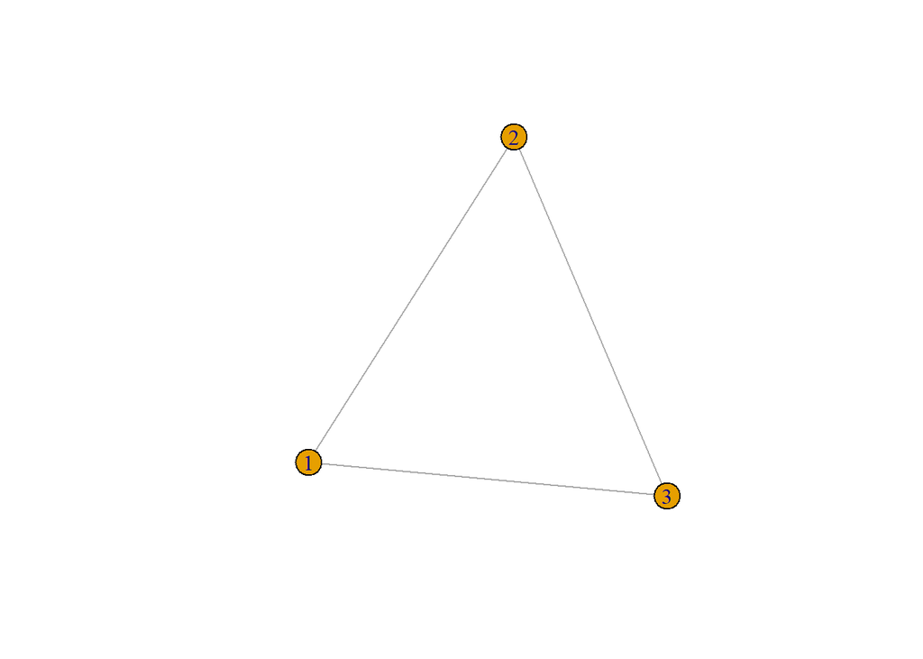

A directed graph is a unique type of graph in which the edges also posses a direction, thus allowing node A to be connected to node B, without node B necessarily being connected to node A. You can think of such connection as one way streets. When plotting a grap we would note such edges with an arrow to signify the direction of connection:

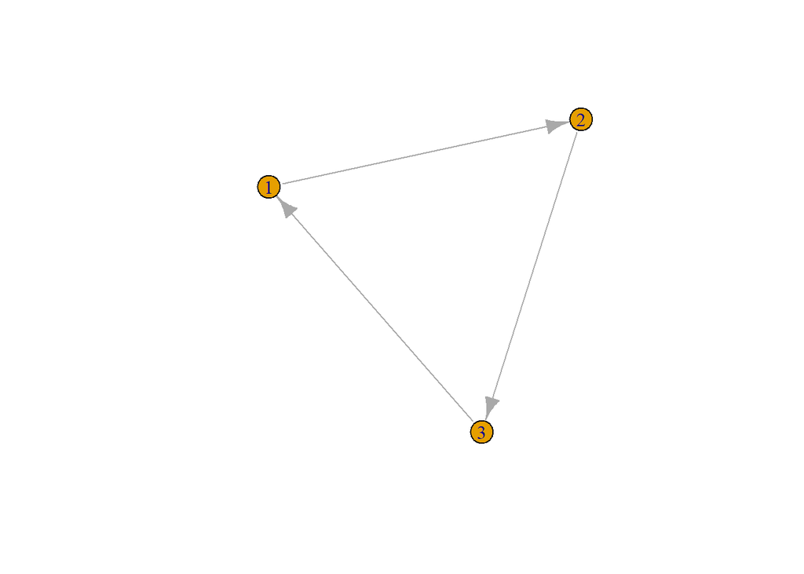

Each node of a graph has a degree, the degree being the value that answers the question “how many edges are connected to this node?”. In a directed graph, logically, we have an “In” degree and and “Out” degree.

In practice, plotting a graph for our case might be a little overkill; we could simply create a matrix of all wrestlers and note where any wrestler is predicted to outrank another. But in reality both those representations are equivalent and it is easy to go from one to another.

### Obtaining the Ranking

After performing the regression model, and predicting the likelihood of each wrestler placing higher than any other wrestler we can make a rule of thumb that any wrestler that is more than 50% likely to be ranked higher will be treated as ranked higher, in practice what we are doing is assigning all instances of prediction above 0.5 to the first class and the rest into the second class. Now, we can use a directed graph to organize the ranking order by arranging the wrestlers by their in degree (the top wrestler would have an in degree of 0, as no wrestler is to be ranked above them, for example).

### Analyzing The Results

Accuracy:

```r
mean(makuuchi_test$next_rank==makuuchi_test$prediction)
```

```
## [1] 0.452381
```

If we first look at the Accuracy metric, the model performs better, but still not amazing. It reaches an accuracy of 0.45, or 45% exact predictions. Comparing that to the regression results, it is nearly a two times improvement.

One-off accuracy:

```r
one_off_acc(makuuchi_test,'next_rank','prediction')
```

```
## [1] 0.8809524
```

In fact, if we look at the one-off accuracy the improves significantly to nearly 90% (accuracy is 0.88). This once again is a significant improvement over the linear regression models.

Finally, if we look at the RMSE:

```r
rmse(makuuchi_test,'next_rank','prediction')$.estimate
```

```
## [1] 1.011835
```

The root mean error is close to 1, further suggesting that most predictions were close, and the were very few (if any) large misses in prediction.

## Discussion and Further Notes

The logistic ranking model delivers a strong estimation of the Banzuke, but still stumbles at the task of fully predicting the ranking (though, as previous “guess the Banzuke” competitions have sown perfectly predicting the ranking is a nigh impossible task).

It is wort noting, though that the model would only achieve a middle of the road results in the prediction competition. This suggests that there are certain patterns and biases not fully accounted for by the model.

While this model is used to predict the top two divisions currently, it is possible to scale it to calculate an entire Banzuke for all divisions, though in this case there would be many redundant comparisons performed, thus making the model very unwieldy. additionally, since the lower divisions have a schedule of 7 matches instead of the full 15, some changes will be required to accommodate for this difference.

## Suggestions for Further Imprvement

One major point of follow up would be a tie breaker rule, while uncommon it is possible for some wrestlers to be close enough in performance that the algorithm has a hard time separating their performance and thus they end up with an identical predicted rank ( a thing that is impossible in the actual ranking), thus a rule for differentiating between those ties will likely make the predictions more reasonable.

Another element that is worth paying attention to is the decision point: 0.5 while a good rule of thumb, is an arbitrary selection. it is possible that a different decision point would yield better results, this would require a more rigorous model selection process.

Finally, a fully connected graph is overkill for the purpose of deciding the ranking, since as a strong preference relationship the Banzuke ranking is transitive (if A>B and B>C, a transitive relation says that it must be that A>C). With this in mind, many of the comparisons are redundant and a more optimal algorithm can be found.

## Conclusion

In conclusion, while all models did not perform exceedingly well in predicting the banzuke, the logistic ranking model is quite consistent in getting within a single placement in its predictions (and avoids making large mistakes). in fact, even the relatively simple and basic regression model does relatively well at estimating ranking positions, but understandably fails in cases when the usual rules do not apply.

Further tinkering and model selection procedures are likely to produce an even stronger prediction, as well as further analysis of the raw data to possibly define other parameters that may come in handy.

Generally, it is clear that while there is some freedom and variation in deciding the banzuke, there are clear patterns and logic to the councils decisions when setting the ranks up.

#### appendix 1: R^2 calculation

to calculate the value for R squared, we need to calculate the values for SST (sum of total squares), and SSR (sum of residual squares) the sum of total squares (SST) is defined to be the sum of square deviations of each value from the mean. the sum of residual squares (SSR) is defined to be the sum of square deviations of each value from the predicted value by the model. Additionally it holds that SST = SSR + SSE. This is true because each deviation from the mean has a part that is explained by the data and is accounted for in the model, and a part that occurs due to other factors (such as inherent randomness, limitations in measurement, or parameters which were not accounted for by the model). The formula for R squared is defined to be: R^2 = 1 - SSR/SST.